# Burn probability time-series metrics

## Overview

Per pixel per year, the fire-detection algorithm produces an intra-annual sequence of burn probabilities at Landsat observation dates. We explore summary metrics derived from that irregular time series to identify which derived quantities best discriminate a true burn signal from noise, slow vegetation stress (drought), or a partial disturbance (deforestation).

## Setup

```r
library(tidyverse)

# Single source of truth for plot styling. Bump `base_size` to scale every font
# in every plot, or tweak individual elements here to update all plots at once.
theme_burn <- function(base_size = 18) {
  theme_minimal(base_size = base_size) +
    theme(
      strip.placement   = "outside",
      strip.text.y.left = element_text(size   = base_size - 2,
                                       margin = margin(r = 6)),
      strip.text.x      = element_text(face   = "bold",
                                       size   = base_size - 1,
                                       margin = margin(b = 6)),
      panel.spacing     = unit(0.85, "lines"),
      panel.grid.minor  = element_blank(),
      panel.grid.major.x = element_blank(),
      panel.grid.major.y = element_line(colour = "grey90", linewidth = 0.35),
      axis.line         = element_line(colour = "grey50", linewidth = 0.4),
      plot.title        = element_text(face   = "bold",
                                       size   = base_size + 2,
                                       margin = margin(b = 6)),
      plot.subtitle     = element_text(size   = base_size - 2,
                                       colour = "grey45",
                                       margin = margin(b = 8)),
      axis.text         = element_text(size = base_size - 2),
      axis.title        = element_text(size = base_size - 1),
      legend.position   = "top",
      legend.box        = "horizontal",
      legend.title      = element_text(size = base_size - 1),
      legend.text       = element_text(size = base_size - 2)
    )
}

theme_set(theme_burn())
```

## Synthetic signals

```r
# Regular sampling at half the previous density (~16.5 d spacing).
n   <- 23
doy <- seq(1, 365, length.out = n)

# Signal shapes are defined directly in DOY space so they survive any change
# in sampling density. Helper for "spike at the obs nearest a target DOY".
idx_at <- function(target_doy) which.min(abs(doy - target_doy))

make_signal <- function(type, peak = 1.0) {
  p <- rep(0.0, n)
  switch(type,
    fire = {
      # peak plateau DOY 73–90, then linear decline to DOY 195
      p <- ifelse(doy < 73,                                  0,
           ifelse(doy <= 90,                                 peak,
           ifelse(doy <= 195, peak * (195 - doy) / (195 - 90), 0)))
    },
    noise = {
      # baseline 0, single high spike near DOY 73
      p[idx_at(73)] <- peak
    },
    noise_down = {
      # baseline 1, single low dip near DOY 276 (later in the year)
      p[]            <- 1.0
      p[idx_at(276)] <- 0.1
    },
    drought = {
      # slow linear increase DOY 17 → 171; linear decline to DOY 349
      p <- ifelse(doy < 17,                                          0,
           ifelse(doy <= 171, peak * (doy - 17)  / (171 - 17),
           ifelse(doy <= 349, peak * (349 - doy) / (349 - 171),      0)))
    },
    deforestation = {
      # peak plateau DOY 73–90, slow decline to DOY 317
      p <- ifelse(doy < 73,                                   0,
           ifelse(doy <= 90,                                  peak,
           ifelse(doy <= 317, peak * (317 - doy) / (317 - 90), 0)))
    }
  )
  p
}

# Each row defines one signal. Multiple rows per `case` are allowed and will be
# overlaid in the same column of the facet grid, distinguished by colour.
# `type` is the signal-generator key (passed to make_signal); `case` is the panel.
signal_specs <- tibble::tribble(
  ~case,           ~type,           ~level,         ~peak,
  "fire",          "fire",          NA_character_,  1.00,
  "noise",         "noise",         "up",           1.00,
  "noise",         "noise_down",    "down",         1.00,
  "drought",       "drought",       NA_character_,  1.00,
  "deforestation", "deforestation", "0.50",         0.50,
  "deforestation", "deforestation", "0.75",         0.75
)
```

## Derived metrics

Let $p_t$ denote the burn probability at observation $t \in \{1, \dots, n\}$ on date $d_t$. Each quantity below is assigned to the indicated date (always **forward** — the date of the earliest observation entering the window, except $\Delta p_t$ which is dated at the second operand).

$$\begin{aligned}
\Delta p_t &= p_t - p_{t-1}, &\quad& d_t \\[2pt]
\Sigma\Delta p^{(2)}_t &= \Delta p_t + \Delta p_{t+1} \;=\; p_{t+1} - p_{t-1}, &\quad& d_t \\[2pt]
\Sigma\Delta p^{(3)}_t &= \Delta p_t + \Delta p_{t+1} + \Delta p_{t+2}
\;=\; p_{t+2} - p_{t-1}, &\quad& d_t \\[2pt]
\bar p^{(2)}_t &= \tfrac{1}{2}\,(p_t + p_{t+1}), &\quad& d_t \\[2pt]
\bar p^{(3)}_t &= \tfrac{1}{3}\,(p_t + p_{t+1} + p_{t+2}), &\quad& d_t \\[2pt]
\pi^{(3)}_t &= p_t \, p_{t+1} \, p_{t+2}, &\quad& d_t \\[2pt]
q^{(3)}_t &= p_t \, p_{t+1} \;+\; p_{t+1} \, p_{t+2}, &\quad& d_t \\[2pt]
J_t &= \Delta p_t \;\cdot\; \min\!\bigl(p_t,\, p_{t+1},\, p_{t+2}\bigr), &\quad& d_t
\end{aligned}$$

The diff-sums telescope to $\Sigma\Delta p^{(k)}_t = p_{t+k-1} - p_{t-1}$, i.e. wider single-step differences — by construction blind to the values between the endpoints. The product $\pi^{(3)}$ and the persistence-gated jump $J$ are both zero whenever any of their factors is zero, so a single-obs spike cannot trigger them. Products are cheap if the upstream model already exposes log-probabilities (e.g. logistic regression): $\log \pi^{(3)}_t = \log p_t + \log p_{t+1} + \log p_{t+2}$.

```r
# For a probability vector p at dates d, compute:
#   pdiff      : p[t] - p[t-1], assigned to forward date t
#   pdiff_sum2 : rolling sum of 2 consecutive diffs, date of first diff
#   pdiff_sum3 : rolling sum of 3 consecutive diffs, date of first diff
#   mean2      : 2-obs forward rolling mean of p, date of first obs
#   mean3      : 3-obs forward rolling mean of p, date of first obs
#   prod3      : 3-obs forward rolling product of p, date of first obs
#                — spike-killer: any zero in the window forces the window to zero
#   q3         : sum of products of consecutive pairs in a 3-obs window,
#                p[t]·p[t+1] + p[t+1]·p[t+2], date of first obs.
#                — fires when the high value is flanked by another high value;
#                  in log-space this is logsumexp(log p[t]+log p[t+1], log p[t+1]+log p[t+2])
#   jump_x_min : (p[t] - p[t-1]) · min(p[t], p[t+1], p[t+2]), date = t
#                — combined: requires both an abrupt jump AND persistence after,
#                  so it suppresses noise (no persistence) and drought (no jump) at once
compute_metrics <- function(p, d) {
  n  <- length(p)
  pd <- diff(p)          # length n-1
  m  <- length(pd)
  pd_doy <- d[-1]        # forward dates for each diff

  list(
    prob       = tibble(doy = d,              value = p),
    pdiff      = tibble(doy = pd_doy,         value = pd),
    pdiff_sum2 = tibble(doy = pd_doy[-m],     value = pd[-m] + pd[-1]),
    pdiff_sum3 = tibble(doy = pd_doy[1:(m-2)],
                        value = pd[1:(m-2)] + pd[2:(m-1)] + pd[3:m]),
    mean2      = tibble(doy = d[-n],          value = (p[-n] + p[-1]) / 2),
    mean3      = tibble(doy = d[1:(n-2)],     value = (p[1:(n-2)] + p[2:(n-1)] + p[3:n]) / 3),
    prod3      = tibble(doy = d[1:(n-2)],     value = p[1:(n-2)] * p[2:(n-1)] * p[3:n]),
    q3         = tibble(doy = d[1:(n-2)],
                        value = p[1:(n-2)] * p[2:(n-1)] + p[2:(n-1)] * p[3:n]),
    jump_x_min = tibble(
      doy   = d[2:(n-2)],
      value = (p[2:(n-2)] - p[1:(n-3)]) *
              pmin(p[2:(n-2)], p[3:(n-1)], p[4:n])
    )
  )
}

var_levels  <- c("prob", "pdiff", "pdiff_sum2", "pdiff_sum3",
                 "mean2", "mean3", "prod3", "q3", "jump_x_min")
case_levels <- c("fire", "noise", "drought", "deforestation")

df <- purrr::pmap_dfr(signal_specs, function(case, type, level, peak) {
  p      <- make_signal(type, peak)
  mets   <- compute_metrics(p, doy)
  sig_id <- if (is.na(level)) type else paste(case, level, sep = "_")
  purrr::map_dfr(var_levels, function(vr) {
    mets[[vr]] |> mutate(
      signal_id = sig_id,
      case      = case,
      level     = level,
      variable  = vr
    )
  })
}) |>
  mutate(
    case      = factor(case,     levels = case_levels),
    variable  = factor(variable, levels = var_levels),
    color_grp = dplyr::case_when(
      case == "noise"         & level == "down" ~ "Alt",
      case == "deforestation" & level == "0.75" ~ "Alt",
      TRUE                                      ~ "Main"
    )
  )
```

## Plot

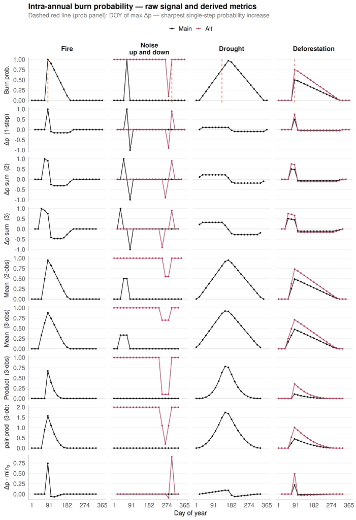

```r
# DOY of max pdiff per case — vertical reference in the prob panel only.
# Multiple signals per case have the same transition DOY in these synthetics,
# so we keep one vline per case.
vline_df <- df |>
  filter(variable == "pdiff") |>
  group_by(signal_id, case) |>
  slice_max(value, n = 1, with_ties = FALSE) |>
  ungroup() |>
  group_by(case) |>
  slice_head(n = 1) |>
  ungroup() |>
  select(case, doy_vline = doy) |>
  mutate(variable = factor("prob", levels = var_levels))

var_labels <- c(
  prob       = "Burn prob.",
  pdiff      = "Δp  (1-step)",
  pdiff_sum2 = "Δp sum  (2)",
  pdiff_sum3 = "Δp sum  (3)",
  mean2      = "Mean  (2-obs)",
  mean3      = "Mean  (3-obs)",
  prod3      = "Product  (3-obs)",
  q3         = "Σ pair-prod  (3-obs)",
  jump_x_min = "Δp · min₃"
)

case_labels <- c(
  fire          = "Fire",
  noise         = "Noise\nup and down",
  drought       = "Drought",
  deforestation = "Deforestation"
)

ggplot(df, aes(x = doy, y = value, group = signal_id, colour = color_grp)) +
  geom_hline(yintercept = 0, colour = "grey80", linewidth = 0.35) +
  geom_line(linewidth = 0.65) +
  geom_point(size = 0.85) +
  geom_vline(
    data        = vline_df,
    aes(xintercept = doy_vline),
    colour      = "tomato",
    linetype    = "dashed",
    linewidth   = 0.7,
    inherit.aes = FALSE
  ) +
  facet_grid(
    variable ~ case,
    scales   = "free_y",
    switch   = "y",
    labeller = labeller(variable = var_labels, case = case_labels)
  ) +
  scale_colour_manual(
    name   = NULL,
    values = c(Main = "#000004", Alt = "#BB3754"),
    breaks = c("Main", "Alt")
  ) +
  scale_x_continuous(
    breaks = c(1, 91, 182, 274, 365),
    labels = c("1", "91", "182", "274", "365")
  ) +
  labs(
    x        = "Day of year",
    y        = NULL,
    title    = "Intra-annual burn probability — raw signal and derived metrics",
    subtitle = "Dashed red line (prob panel): DOY of max Δp — sharpest single-step probability increase"
  )
```

## Irregular sampling: penalising long gaps

All metrics above treat $\Delta p_t = p_t - p_{t-1}$ as instantaneous — they ignore the elapsed time between observations $t-1$ and $t$. Landsat sampling is far from regular: clouds, scene failures, and the L8+L9 combined revisit (~8 d) produce gaps that can stretch to weeks or months. Under irregular sampling, a *slow* drought sampled across a long gap can produce a $\Delta p$ that visually mimics a *fast* fire transition.

Dividing by $\Delta t$ (a rate) overcorrects — it penalises *every* non-zero gap linearly, including the 8–30 day gaps that are still perfectly trustworthy. Instead, we apply a **soft gap-penalty weight** that is essentially 1 for short gaps and saturates to 0 for long ones. A stretched-exponential (Weibull survival) shape — slow near zero, then dropping fast — has exactly that behaviour:

$$w(\tau) \;=\; \exp\!\bigl[-(\tau/\tau_0)^{k}\bigr], \qquad \tau_0 = 40\ \text{d},\ k = 4$$

The exponent $k = 4$ keeps the curve flat near 0; with $k = 1$ it would be plain exponential and start dropping immediately. With 16 d regular sampling, normal gaps land deep in the flat region; the curve falls sharply across 30–60 d. Numerically: $w(15\,\text{d}) \approx 0.98$, $w(30\,\text{d}) \approx 0.73$, $w(45\,\text{d}) \approx 0.20$, $w(60\,\text{d}) \approx 0.006$.

The gap-weighted persistence-gated jump is

$$J^{w}_t \;=\; (p_t - p_{t-1}) \cdot w(\tau_t) \cdot \min\!\bigl(p_t,\, p_{t+1},\, p_{t+2}\bigr),$$

with $\tau_t = d_t - d_{t-1}$ the gap (in days) immediately preceding observation $t$.

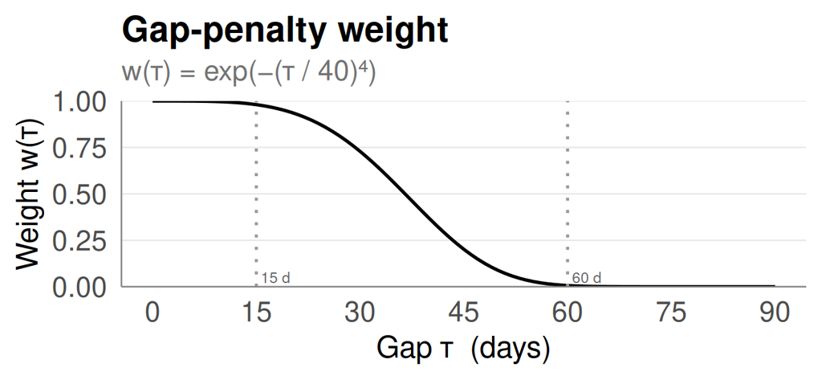

```r
gap_weight <- function(tau_days, tau0 = 40, k = 4) {
  exp(-(tau_days / tau0)^k)
}

tibble(tau = seq(0, 90, by = 1), w = gap_weight(tau)) |>
  ggplot(aes(tau, w)) +
  geom_line(linewidth = 0.9, colour = "#000004") +
  geom_vline(xintercept = c(15, 60), colour = "grey60", linetype = "dotted") +
  annotate("text", x = 15, y = 0.05, label = "15 d", hjust = -0.15, size = 3, colour = "grey40") +
  annotate("text", x = 60, y = 0.05, label = "60 d", hjust = -0.15, size = 3, colour = "grey40") +
  scale_y_continuous(limits = c(0, 1), expand = c(0, 0)) +
  scale_x_continuous(breaks = seq(0, 90, by = 15)) +
  labs(
    x        = "Gap τ  (days)",
    y        = "Weight w(τ)",
    title    = "Gap-penalty weight",
    subtitle = "w(τ) = exp(−(τ / 40)⁴)"
  )
```

```r
# Sparse drought: keep only ~17 obs over the year (gaps up to ~50 d in the
# early part, dense from obs 11 onward).
sparse_keep <- c(1L, 3L, 5L, 8L, 11L:n)

build_obs <- function(case, peak, keep = seq_len(n)) {
  p_full <- make_signal(case, peak)
  list(p = p_full[keep], d = doy[keep])
}

signals2 <- list(
  fire              = list(case = "fire",           level = NA_character_,
                           obs = build_obs("fire",          1.00)),
  noise_up          = list(case = "noise",          level = "up",
                           obs = build_obs("noise",         1.00)),
  noise_down        = list(case = "noise",          level = "down",
                           obs = build_obs("noise_down",    1.00)),
  drought           = list(case = "drought",        level = NA_character_,
                           obs = build_obs("drought",       1.00)),
  drought_sparse    = list(case = "drought_sparse", level = NA_character_,
                           obs = build_obs("drought",       1.00, sparse_keep)),
  deforestation_050 = list(case = "deforestation",  level = "0.50",
                           obs = build_obs("deforestation", 0.50)),
  deforestation_075 = list(case = "deforestation",  level = "0.75",
                           obs = build_obs("deforestation", 0.75))
)

compute_jw <- function(p, d) {
  nn  <- length(p)
  pd  <- diff(p)              # length nn - 1
  tau <- diff(d)              # gap in days, length nn - 1
  w   <- gap_weight(tau)      # length nn - 1
  fwd <- d[-1]                # forward date for each diff / each gap

  idx       <- 1:(nn - 3)     # for jump: t = 2..(nn - 2)
  jx_doy    <- fwd[idx]
  persist3  <- pmin(p[2:(nn - 2)], p[3:(nn - 1)], p[4:nn])
  j_agn     <- pd[idx]            * persist3   # time-agnostic = jump_x_min
  j_w       <- pd[idx] * w[idx]   * persist3   # gap-weighted

  list(
    prob       = tibble(doy = d,        value = p),
    weight     = tibble(doy = fwd,      value = w),
    jump_x_min = tibble(doy = jx_doy,   value = j_agn),
    jump_w     = tibble(doy = jx_doy,   value = j_w)
  )
}

var2_levels  <- c("prob", "weight", "jump_x_min", "jump_w")
case2_levels <- c("fire", "noise", "drought", "drought_sparse", "deforestation")

df2 <- purrr::imap_dfr(signals2, function(sig, sig_id) {
  mets <- compute_jw(sig$obs$p, sig$obs$d)
  purrr::map_dfr(var2_levels, function(vr) {
    mets[[vr]] |> mutate(
      signal_id = sig_id,
      case      = sig$case,
      level     = sig$level,
      variable  = vr
    )
  })
}) |>
  mutate(
    case      = factor(case,     levels = case2_levels),
    variable  = factor(variable, levels = var2_levels),
    color_grp = dplyr::case_when(
      case == "noise"         & level == "down" ~ "Alt",
      case == "deforestation" & level == "0.75" ~ "Alt",
      TRUE                                      ~ "Main"
    )
  )
```

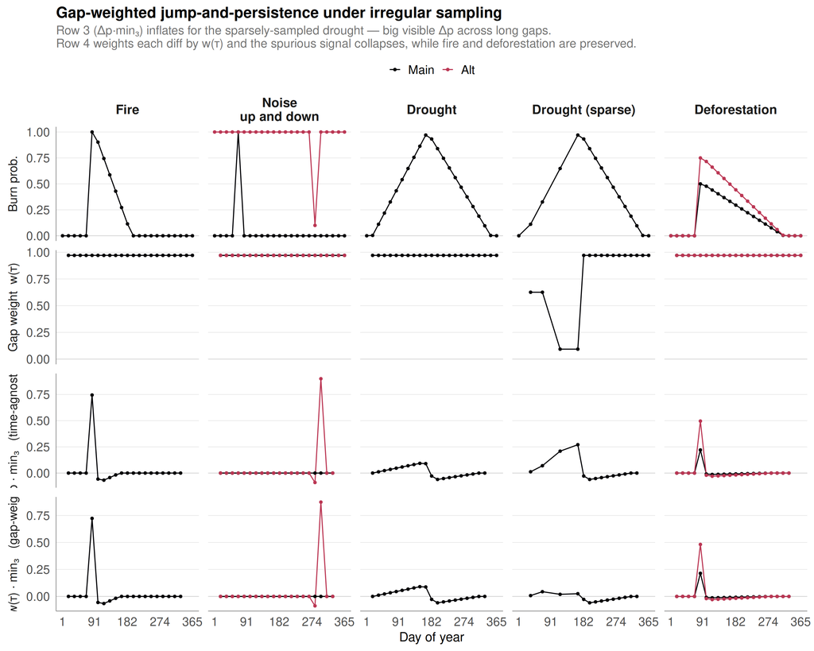

```r
case2_labels <- c(
  fire           = "Fire",
  noise          = "Noise\nup and down",
  drought        = "Drought",
  drought_sparse = "Drought (sparse)",
  deforestation  = "Deforestation"
)

var2_labels <- c(
  prob       = "Burn prob.",
  weight     = "Gap weight  w(τ)",
  jump_x_min = "Δp · min₃   (time-agnostic)",
  jump_w     = "Δp · w(τ) · min₃   (gap-weighted)"
)

ggplot(df2, aes(x = doy, y = value,
                group = signal_id, colour = color_grp)) +
  geom_hline(yintercept = 0, colour = "grey80", linewidth = 0.35) +
  geom_line(linewidth = 0.65) +
  geom_point(size = 1.1) +
  facet_grid(
    variable ~ case,
    scales   = "free_y",
    switch   = "y",
    labeller = labeller(variable = var2_labels, case = case2_labels)
  ) +
  scale_colour_manual(
    name   = NULL,
    values = c(Main = "#000004", Alt = "#BB3754"),
    breaks = c("Main", "Alt")
  ) +
  scale_x_continuous(breaks = c(1, 91, 182, 274, 365)) +
  labs(
    x        = "Day of year",
    y        = NULL,
    title    = "Gap-weighted jump-and-persistence under irregular sampling",
    subtitle = "Row 3 (Δp·min₃) inflates for the sparsely-sampled drought — big visible Δp across long gaps.\nRow 4 weights each diff by w(τ) and the spurious signal collapses, while fire and deforestation are preserved."
  )
```

## Per-observation features for SNIC seeds and candidates

Rather than collapse everything into one composite, we expose each per-obs quantity as a feature, so the downstream SNIC seed/candidate logic can weight them independently. The feature vector at observation $t$ (in a pixel with $N^{\text{obs}}_{\text{year}}$ valid annual observations) is:

- **Diff certainty** $\tau^{\text{pre}}_t = d_t - d_{t-1}$ (days, smaller = better; soft weight $w(\tau^{\text{pre}}_t)$).
- **Persistence span** $\tau^{\text{post}}_t = d_{t+2} - d_t$ (days; larger = stronger persistence *within* a cap).
- **Adaptive persistence** — fixed-$k = 3$ when sampling is dense, falling back to $k = 2$ when too sparse:
  $$\operatorname{persist}^{\text{adapt}}_t \;=\;
  \begin{cases}
  \min(p_t,\, p_{t+1},\, p_{t+2}) & \text{if } \tau^{\text{post}}_t \le \tau_{\max} \\
  \min(p_t,\, p_{t+1}) & \text{otherwise}
  \end{cases}
  \qquad \tau_{\max} = 60\,\text{d}$$
- **Annual obs count** $N^{\text{obs}}_{\text{year}}$ (pixel-level scalar; low values down-weight everything).
- **Composite** $J^{w,\text{adapt}}_t = (p_t - p_{t-1}) \cdot w(\tau^{\text{pre}}_t) \cdot \operatorname{persist}^{\text{adapt}}_t$.

**Seed** (strict): $J^{w,\text{adapt}}_t \ge 0.5$ AND $\tau^{\text{pre}}_t \le 30$ d AND $\tau^{\text{post}}_t \le 60$ d AND $N^{\text{obs}}_{\text{year}} \ge 35$.

**Candidate** (permissive): $J^{w,\text{adapt}}_t \ge 0.15$ AND $\tau^{\text{pre}}_t \le 60$ d AND $N^{\text{obs}}_{\text{year}} \ge 20$.

SNIC then grows segments from seeds; candidates attach if spatially consistent. Isolated candidates (e.g., a single drought pixel flagged across a long pre-jump gap) get rejected for lack of neighbour support.

```r
# Adaptive persistence: 3-obs min when the window's time span ≤ tau_max,
# otherwise fall back to 2-obs min (and to p[t] alone at the trailing edge).
persist_adapt_fn <- function(p, d, tau_max = 60) {
  nn       <- length(p)
  p3       <- rep(NA_real_, nn)
  p2       <- rep(NA_real_, nn)
  tau_post <- rep(NA_real_, nn)
  if (nn >= 3) {
    p3[1:(nn - 2)]       <- pmin(p[1:(nn - 2)], p[2:(nn - 1)], p[3:nn])
    tau_post[1:(nn - 2)] <- d[3:nn] - d[1:(nn - 2)]
  }
  if (nn >= 2) p2[1:(nn - 1)] <- pmin(p[1:(nn - 1)], p[2:nn])

  out <- p
  out <- ifelse(!is.na(p2), p2, out)
  out <- ifelse(!is.na(p3) & !is.na(tau_post) & tau_post <= tau_max, p3, out)
  out
}

compute_snic_features <- function(p, d,
                                   tau_max       = 60,
                                   theta_high    = 0.5,
                                   theta_low     = 0.15,
                                   tau_pre_seed  = 30,
                                   tau_pre_cand  = 60,
                                   tau_post_seed = 60,
                                   n_min_seed    = 35,
                                   n_min_cand    = 20) {
  nn         <- length(p)
  n_obs_year <- nn

  tau_pre  <- c(NA_real_, diff(d))
  tau_post <- if (nn >= 3) c(d[3:nn] - d[1:(nn - 2)], NA_real_, NA_real_)
              else rep(NA_real_, nn)
  w_pre    <- gap_weight(tau_pre)

  persist_adapt <- persist_adapt_fn(p, d, tau_max = tau_max)
  dp            <- c(NA_real_, diff(p))
  J_w_adapt     <- dp * w_pre * persist_adapt

  is_seed <- !is.na(J_w_adapt) & J_w_adapt >= theta_high &
             !is.na(tau_pre)   & tau_pre   <= tau_pre_seed &
             !is.na(tau_post)  & tau_post  <= tau_post_seed &
             n_obs_year >= n_min_seed

  is_cand <- !is.na(J_w_adapt) & J_w_adapt >= theta_low &
             !is.na(tau_pre)   & tau_pre   <= tau_pre_cand &
             n_obs_year >= n_min_cand

  tibble(
    doy           = d,
    p             = p,
    tau_pre       = tau_pre,
    tau_post      = tau_post,
    w_pre         = w_pre,
    persist_adapt = persist_adapt,
    dp            = dp,
    J_w_adapt     = J_w_adapt,
    n_obs_year    = n_obs_year,
    flag          = factor(
      dplyr::case_when(is_seed ~ "seed", is_cand ~ "candidate", TRUE ~ "none"),
      levels = c("none", "candidate", "seed")
    )
  )
}

df3 <- purrr::imap_dfr(signals2, function(sig, sig_id) {
  feats <- compute_snic_features(sig$obs$p, sig$obs$d)
  feats |> mutate(
    signal_id = sig_id,
    case      = sig$case,
    level     = sig$level
  )
}) |>
  mutate(
    case      = factor(case, levels = case2_levels),
    color_grp = dplyr::case_when(
      case == "noise"         & level == "down" ~ "Alt",
      case == "deforestation" & level == "0.75" ~ "Alt",
      TRUE                                      ~ "Main"
    )
  )
```

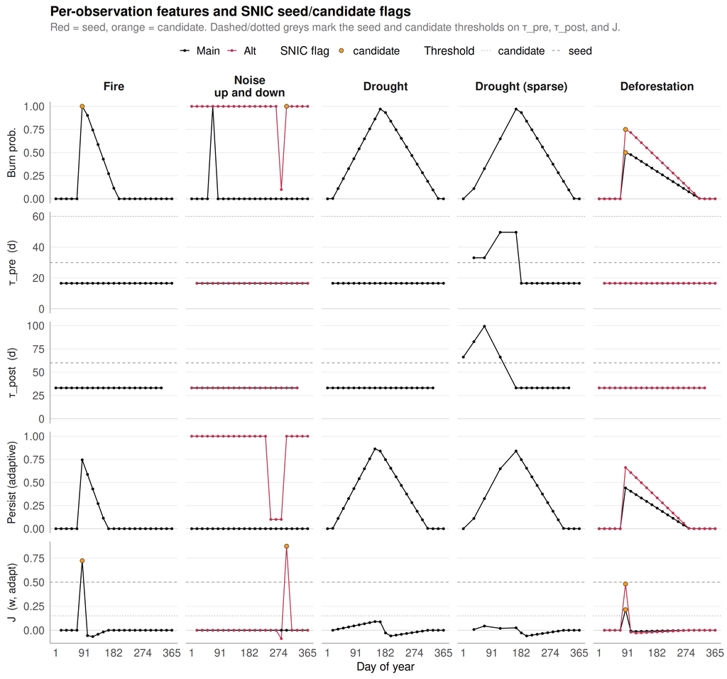

```r
var3_levels <- c("prob", "tau_pre", "tau_post", "persist_adapt", "J_w_adapt")

var3_labels <- c(
  prob          = "Burn prob.",
  tau_pre       = "τ_pre  (d)",
  tau_post      = "τ_post  (d)",
  persist_adapt = "Persist (adaptive)",
  J_w_adapt     = "J  (w, adapt)"
)

df3_long <- df3 |>
  select(doy, signal_id, case, color_grp, flag,
         prob = p, tau_pre, tau_post, persist_adapt, J_w_adapt) |>
  tidyr::pivot_longer(c(prob, tau_pre, tau_post, persist_adapt, J_w_adapt),
                      names_to = "variable", values_to = "value") |>
  mutate(variable = factor(variable, levels = var3_levels))

# Threshold reference lines per row
hlines_df <- tibble::tribble(
  ~variable,    ~yintercept, ~thr_type,
  "tau_pre",    30,          "seed",
  "tau_pre",    60,          "candidate",
  "tau_post",   60,          "seed",
  "J_w_adapt",  0.5,         "seed",
  "J_w_adapt",  0.15,        "candidate"
) |>
  mutate(variable = factor(variable, levels = var3_levels))

# Flag markers — only on the prob and J_w_adapt rows
flag_markers <- df3_long |>
  filter(variable %in% c("prob", "J_w_adapt"), flag != "none")

ggplot(df3_long, aes(x = doy, y = value,
                     group = signal_id, colour = color_grp)) +
  geom_hline(yintercept = 0, colour = "grey80", linewidth = 0.35) +
  geom_hline(
    data        = hlines_df,
    aes(yintercept = yintercept, linetype = thr_type),
    colour      = "grey55",
    linewidth   = 0.45,
    inherit.aes = FALSE
  ) +
  geom_line(linewidth = 0.6) +
  geom_point(size = 0.85) +
  geom_point(
    data        = flag_markers,
    aes(x = doy, y = value, fill = flag),
    shape       = 21,
    colour      = "grey20",
    size        = 2.6,
    stroke      = 0.5,
    inherit.aes = FALSE
  ) +
  facet_grid(
    variable ~ case,
    scales   = "free_y",
    switch   = "y",
    labeller = labeller(variable = var3_labels, case = case2_labels)
  ) +
  scale_colour_manual(
    name   = NULL,
    values = c(Main = "#000004", Alt = "#BB3754"),
    breaks = c("Main", "Alt")
  ) +
  scale_fill_manual(
    name   = "SNIC flag",
    values = c(seed = "#e31a1c", candidate = "#ff9b1f")
  ) +
  scale_linetype_manual(
    name   = "Threshold",
    values = c(seed = "dashed", candidate = "dotted")
  ) +
  scale_x_continuous(breaks = c(1, 91, 182, 274, 365)) +
  labs(
    x        = "Day of year",
    y        = NULL,
    title    = "Per-observation features and SNIC seed/candidate flags",
    subtitle = "Red = seed, orange = candidate. Dashed/dotted greys mark the seed and candidate thresholds on τ_pre, τ_post, and J."
  )
```

## Special case: low-severity forest burns (Patagonia)

In Patagonian forests, **low-severity fires can kill the canopy on a delayed schedule** — the burn probability rises slowly over weeks to months rather than jumping abruptly. To the focal jumper $J^{w,\text{adapt}}_t$ this looks indistinguishable from drought, and the SNIC seed/candidate criteria above will not fire because $\Delta p_t$ stays small at every individual step.

The discriminating signature is the *combination* of: a real, sustained probability after the slow rise (unlike drought, which recovers); a pre-disturbance state that was clearly healthy forest; and the *absence* of any sharp-edged signal — both in the year of interest and in the previous year.

**Candidate criterion** — forest class, Patagonia only, candidates only (never seeds, because we have no reliable transition date):

$$\begin{aligned}
&\max_t \,\operatorname{persist}^{\text{adapt}}_{Y,\,t} &&\ge\, \theta_{\text{persist}} && \text{(crown does die — unlike drought)} \\
\wedge\;&\,\text{NDVI}^{\text{wet}}_{Y-1} &&\ge\, \theta_{\text{NDVI}} && \text{(was a healthy forest)} \\
\wedge\;&\max_t \, J^{w,\text{adapt}}_{Y,\,t} &&\le\, \theta_{J,\,\text{low}} && \text{(no abrupt jump this year — unlike fire)} \\
\wedge\;&\max_t \, J^{w,\text{adapt}}_{Y-1,\,t} &&\le\, \theta_{J,\,\text{low}} && \text{(no abrupt jump last year either)} \\
\wedge\;&\,\text{land cover}_{Y-1} &&=\, \text{forest} && \\
\wedge\;&\,\text{region} &&=\, \text{PAT} &&
\end{aligned}$$

The two annual-max constraints are the key. They together separate this regime from the three nearest distractors:

| Distractor | What breaks the criterion |
| --- | --- |
| Drought (slow rise, full recovery) | $\max_t \operatorname{persist}^{\text{adapt}}_{Y,t}$ stays low — the prob returns to zero |
| Regular fire (sharp transition) | $\max_t J^{w,\text{adapt}}_{Y,t}$ is high — fails the “low jumper this year” check |
| Burned previous year, still looks dead | $\max_t J^{w,\text{adapt}}_{Y-1,t}$ is high — fails the “low jumper last year” check |
| Non-forest land cover with similar dynamics | Fails the land-cover gate |

These pixels enter SNIC strictly as **candidates** for the forest fire class, never as seeds. They depend on spatial coherence with neighbouring sharp-edge fire seeds to be retained — a delayed-mortality patch typically borders the higher-severity core, so the candidate ring attaches to the seed-anchored segment.

The criterion is intentionally narrow: it would generate many false positives if applied outside forest land cover or outside Patagonia, where slow-mortality dynamics have different causes (e.g., agriculture rotation, shrub senescence).

## MapBiomas workshop

Drought is replaced by a **Gaussian bell** ($\sigma = 30\,\text{d}$) so the signal is symmetric and reaches exactly 1 at the centre. The sparse drought retains only three observations before the peak — the last at DOY ≈ 117 where the bell evaluates to ≈ 0.09 — producing a visible ~0.1 → 1 jump under time-agnostic metrics. Fire has two severity levels (1.0 and 0.8); deforestation has peaks at 0.5 and 0.7. The noise panel shows both an up-spike (baseline 0 → 1 near DOY 73) and a down-dip (baseline 1 → 0.1 near DOY 276) so the “noise looks like burn” failure mode is visible in both directions.

```r
mu_bell    <- doy[idx_at(180)]   # peak obs nearest mid-year (DOY ≈ 182.5)
sigma_bell <- 30                 # days

make_signal_bell <- function(type, peak = 1.0) {
  p <- rep(0.0, n)
  switch(type,
    fire = {
      p <- ifelse(doy < 73,                                  0,
           ifelse(doy <= 90,                                 peak,
           ifelse(doy <= 195, peak * (195 - doy) / (195 - 90), 0)))
    },
    noise = {
      p[idx_at(73)] <- peak
    },
    noise_down = {
      p[]            <- 1.0
      p[idx_at(276)] <- 0.1
    },
    drought = {
      p <- peak * exp(-((doy - mu_bell)^2) / (2 * sigma_bell^2))
    },
    deforestation = {
      p <- ifelse(doy < 73,                                   0,
           ifelse(doy <= 90,                                  peak,
           ifelse(doy <= 317, peak * (317 - doy) / (317 - 90), 0)))
    }
  )
  p
}

# Sparse drought: obs 1, 4, 8 before peak; dense from obs 11 onward.
# At obs 8 (DOY ≈ 117): bell ≈ 0.09 → jump to ≈ 0.86 at obs 11 (DOY ≈ 166).
sparse_keep_bell <- c(1L, 4L, 8L, 11L:n)

build_obs_bell <- function(case, peak, keep = seq_len(n)) {
  p_full <- make_signal_bell(case, peak)
  list(p = p_full[keep], d = doy[keep])
}

signals_ws <- list(
  fire_100          = list(case = "fire",           level = "1.00",
                           obs = build_obs_bell("fire",          1.00)),
  fire_080          = list(case = "fire",           level = "0.80",
                           obs = build_obs_bell("fire",          0.80)),
  noise_up          = list(case = "noise",          level = "up",
                           obs = build_obs_bell("noise",         1.00)),
  noise_down        = list(case = "noise",          level = "down",
                           obs = build_obs_bell("noise_down",    1.00)),
  drought           = list(case = "drought",        level = NA_character_,
                           obs = build_obs_bell("drought",       1.00)),
  drought_sparse    = list(case = "drought_sparse", level = NA_character_,
                           obs = build_obs_bell("drought",       1.00, sparse_keep_bell)),
  deforestation_050 = list(case = "deforestation",  level = "0.50",
                           obs = build_obs_bell("deforestation", 0.50)),
  deforestation_070 = list(case = "deforestation",  level = "0.70",
                           obs = build_obs_bell("deforestation", 0.70))
)

# 5-obs forward rolling median dated at the middle (3rd) observation.
compute_ws1 <- function(p, d) {
  nn      <- length(p)
  valid_n <- max(nn - 4L, 0L)

  if (valid_n > 0L) {
    med5_val <- vapply(seq_len(valid_n),
                       function(i) median(p[i:(i + 4L)]),
                       numeric(1))
    med5_doy <- d[seq_len(valid_n) + 2L]   # middle obs of each 5-obs window
  } else {
    med5_val <- numeric(0)
    med5_doy <- numeric(0)
  }

  dm5 <- diff(med5_val)
  # Gap between consecutive med5 dates = gap between the two middle obs of the
  # rolling windows. We use this gap to soften the product near long gaps.
  gw_med <- if (length(med5_doy) >= 2) gap_weight(diff(med5_doy)) else numeric(0)

  list(
    prob        = tibble(doy = d,             value = p),
    median5     = tibble(doy = med5_doy,      value = med5_val),
    diff_med5   = tibble(doy = med5_doy[-1],  value = dm5),
    prod_med5   = tibble(doy = med5_doy[-1],  value = dm5 * med5_val[-1]),
    delta_t     = tibble(doy = d[-1],         value = diff(d)),
    prod_med5_w = tibble(doy = med5_doy[-1],  value = dm5 * med5_val[-1] * gw_med)
  )
}

var_ws1_levels <- c("prob", "median5", "diff_med5", "prod_med5",
                    "delta_t", "prod_med5_w")

df_ws1 <- purrr::imap_dfr(signals_ws, function(sig, sig_id) {
  mets <- compute_ws1(sig$obs$p, sig$obs$d)
  purrr::map_dfr(var_ws1_levels, function(vr) {
    mets[[vr]] |> mutate(
      signal_id = sig_id,
      case      = sig$case,
      level     = sig$level,
      variable  = vr
    )
  })
}) |>
  mutate(
    case      = factor(case,     levels = case2_levels),
    variable  = factor(variable, levels = var_ws1_levels),
    color_grp = dplyr::case_when(
      case == "fire"          & level == "0.80" ~ "Alt",
      case == "noise"         & level == "down" ~ "Alt",
      case == "deforestation" & level == "0.70" ~ "Alt",
      TRUE                                      ~ "Main"
    )
  )
```

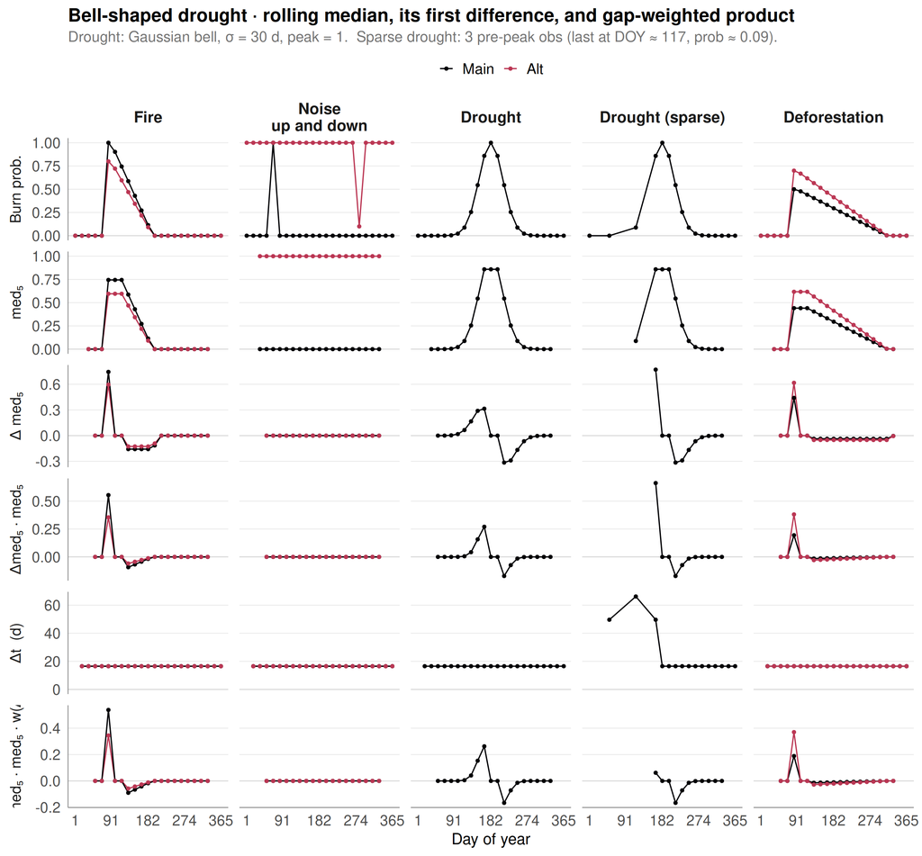

```r
var_ws1_labels <- c(
  prob        = "Burn prob.",
  median5     = "med₅",
  diff_med5   = "Δ med₅",
  prod_med5   = "Δmed₅ · med₅",
  delta_t     = "Δt  (d)",
  prod_med5_w = "Δmed₅ · med₅ · w(Δt)"
)

ggplot(df_ws1, aes(x = doy, y = value,
                   group = signal_id, colour = color_grp)) +
  geom_hline(yintercept = 0, colour = "grey80", linewidth = 0.35) +
  geom_line(linewidth = 0.65) +
  geom_point(size = 1.1) +
  facet_grid(
    variable ~ case,
    scales   = "free_y",
    switch   = "y",
    labeller = labeller(variable = var_ws1_labels, case = case2_labels)
  ) +
  scale_colour_manual(
    name   = NULL,
    values = c(Main = "#000004", Alt = "#BB3754"),
    breaks = c("Main", "Alt")
  ) +
  scale_x_continuous(breaks = c(1, 91, 182, 274, 365)) +
  labs(
    x        = "Day of year",
    y        = NULL,
    title    = "Bell-shaped drought · rolling median, its first difference, and gap-weighted product",
    subtitle = paste0(
      "Drought: Gaussian bell, σ = 30 d, peak = 1.  ",
      "Sparse drought: 3 pre-peak obs (last at DOY ≈ 117, prob ≈ 0.09)."
    )
  )
```

```r
# dp[t]   = p[t] - p[t-1], dated at d[t]   (t = 2..nn)
# min3[t] = min(p[t], p[t+1], p[t+2]), dated at d[t]   (t = 1..nn-2)
# jumper  = dp[t] * min3[t], overlap at t = 2..nn-2
compute_ws2 <- function(p, d) {
  nn       <- length(p)
  dp_val   <- diff(p)
  min3_val <- pmin(p[1:(nn - 2)], p[2:(nn - 1)], p[3:nn])
  delta_t  <- diff(d)                                # length nn - 1
  gw_dp    <- gap_weight(delta_t)                    # weight for each Δp

  list(
    prob     = tibble(doy = d,               value = p),
    dp       = tibble(doy = d[-1],           value = dp_val),
    min3     = tibble(doy = d[1:(nn - 2)],   value = min3_val),
    jumper   = tibble(doy = d[2:(nn - 2)],
                      value = dp_val[1:(nn - 3)] * min3_val[2:(nn - 2)]),
    delta_t  = tibble(doy = d[-1],           value = delta_t),
    jumper_w = tibble(doy = d[2:(nn - 2)],
                      value = dp_val[1:(nn - 3)] * min3_val[2:(nn - 2)] *
                              gw_dp[1:(nn - 3)])
  )
}

var_ws2_levels <- c("prob", "min3", "dp", "jumper", "delta_t", "jumper_w")

df_ws2 <- purrr::imap_dfr(signals_ws, function(sig, sig_id) {
  mets <- compute_ws2(sig$obs$p, sig$obs$d)
  purrr::map_dfr(var_ws2_levels, function(vr) {
    mets[[vr]] |> mutate(
      signal_id = sig_id,
      case      = sig$case,
      level     = sig$level,
      variable  = vr
    )
  })
}) |>
  mutate(
    case      = factor(case,     levels = case2_levels),
    variable  = factor(variable, levels = var_ws2_levels),
    color_grp = dplyr::case_when(
      case == "fire"          & level == "0.80" ~ "Alt",
      case == "noise"         & level == "down" ~ "Alt",
      case == "deforestation" & level == "0.70" ~ "Alt",
      TRUE                                      ~ "Main"
    )
  )
```

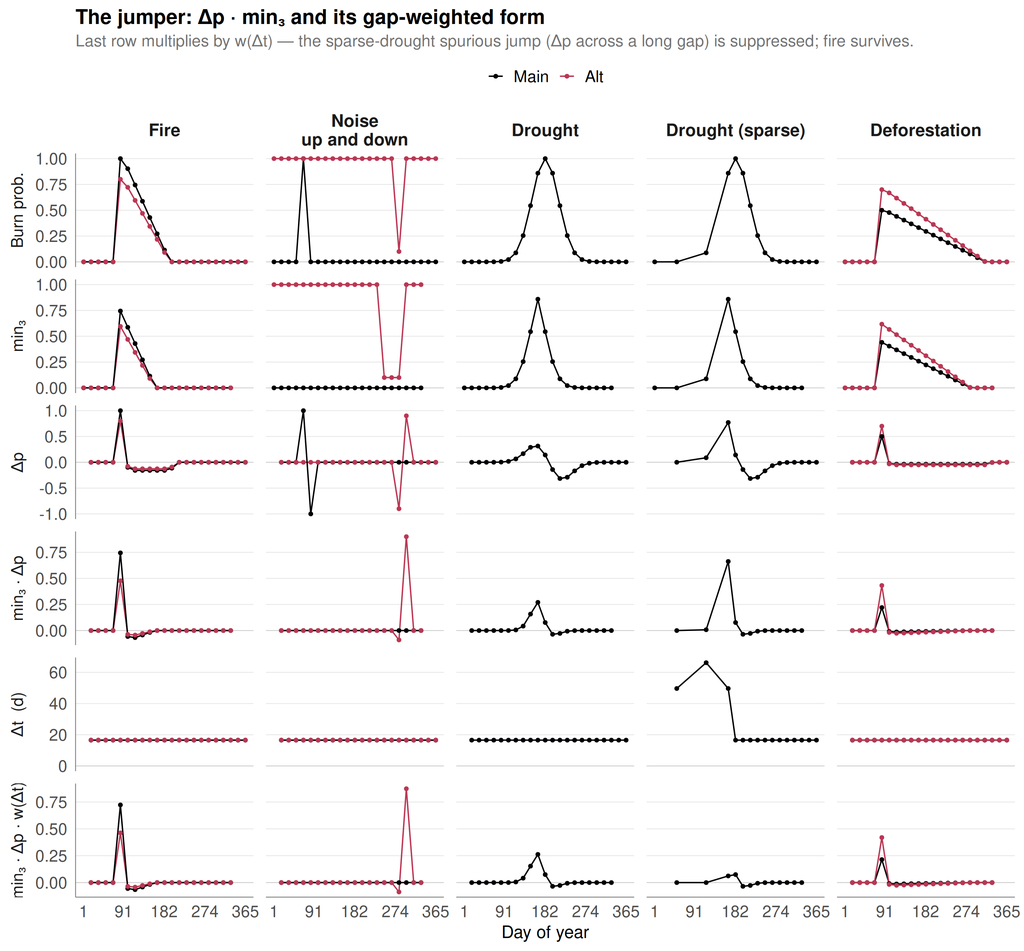

```r
var_ws2_labels <- c(
  prob     = "Burn prob.",
  min3     = "min₃",
  dp       = "Δp",
  jumper   = "min₃ · Δp",
  delta_t  = "Δt  (d)",
  jumper_w = "min₃ · Δp · w(Δt)"
)

ggplot(df_ws2, aes(x = doy, y = value,
                   group = signal_id, colour = color_grp)) +
  geom_hline(yintercept = 0, colour = "grey80", linewidth = 0.35) +
  geom_line(linewidth = 0.65) +
  geom_point(size = 1.1) +
  facet_grid(
    variable ~ case,
    scales   = "free_y",
    switch   = "y",
    labeller = labeller(variable = var_ws2_labels, case = case2_labels)
  ) +
  scale_colour_manual(
    name   = NULL,
    values = c(Main = "#000004", Alt = "#BB3754"),
    breaks = c("Main", "Alt")
  ) +
  scale_x_continuous(breaks = c(1, 91, 182, 274, 365)) +
  labs(
    x        = "Day of year",
    y        = NULL,
    title    = "The jumper: Δp · min₃ and its gap-weighted form",
    subtitle = "Last row multiplies by w(Δt) — the sparse-drought spurious jump (Δp across a long gap) is suppressed; fire survives."
  )
```

## Pre-jump baseline: `p[t-1]` vs `max₂` vs `mean₂` back

The jump is `Δ_t = minfore_t − baseline_t`, with the forward persistence term `minfore_t = min(p_t, p_{t+1}, p_{t+2})` fixed and three choices for the pre-jump baseline:

- **`p[t-1]`** — the single latest observation. Most local: under sparse (cloud-dropped) sampling it never reaches back to a possibly-stale `t-2` obs. But it is noisy — a dip at `t-1` inflates the jump (false positive), a spike at `t-1` kills it (omission).
- **`max₂ back = max(p_{t-2}, p_{t-1})`** — the most conservative (“minimum plausible jump” = smallest-forward − largest-backward). Robust to a transient pre-period *dip*, but a single pre-period *spike* suppresses the jump. **On a monotone run this equals `diff(median₅)`** (and equals `p[t-1]`). Natural **seed** estimator.
- **`mean₂ back = ½(p_{t-2} + p_{t-1})`** — variance-reduced compromise, but on a slow ramp it averages in the lower `t-2` value and so **inflates** the jump (~1.5 steps), weakening drought rejection.

All three coincide on a clean monotone increase (where `p[t-1] = max₂ = med₅[t-1]`); they diverge only under pre-period noise and on slow ramps. Δ is dated at `d_t` (anchor `t = 3 … n-2`).

```r
# Three pre-jump baseline estimators, all paired with the same forward
# persistence term minfore = min(p[t], p[t+1], p[t+2]):
#   prev     : p[t-1]                (single latest obs; most local, noisiest)
#   maxback  : max(p[t-2], p[t-1])   (conservative; = diff(median5) on monotone runs)
#   meanback : mean(p[t-2], p[t-1])  (variance-reduced; inflates Δ on slow ramps)
# delta_* = minfore - baseline, dated at d[t]. Valid anchor t = 3..(n-2).
compute_ws3 <- function(p, d) {
  nn <- length(p)
  if (nn < 5) return(list())
  t_idx    <- 3:(nn - 2)
  minfore  <- pmin(p[3:(nn - 2)], p[4:(nn - 1)], p[5:nn])
  prev     <- p[2:(nn - 3)]
  maxback  <- pmax(p[1:(nn - 4)], p[2:(nn - 3)])
  meanback <- (p[1:(nn - 4)] + p[2:(nn - 3)]) / 2
  doy_t    <- d[t_idx]

  list(
    prob       = tibble(doy = d,     value = p),
    minfore    = tibble(doy = doy_t, value = minfore),
    delta_prev = tibble(doy = doy_t, value = minfore - prev),
    delta_max  = tibble(doy = doy_t, value = minfore - maxback),
    delta_mean = tibble(doy = doy_t, value = minfore - meanback)
  )
}

var_ws3_levels <- c("prob", "minfore", "delta_prev", "delta_max", "delta_mean")

df_ws3 <- purrr::imap_dfr(signals_ws, function(sig, sig_id) {
  mets <- compute_ws3(sig$obs$p, sig$obs$d)
  purrr::map_dfr(var_ws3_levels, function(vr) {
    mets[[vr]] |> mutate(
      signal_id = sig_id,
      case      = sig$case,
      level     = sig$level,
      variable  = vr
    )
  })
}) |>
  mutate(
    case      = factor(case,     levels = case2_levels),
    variable  = factor(variable, levels = var_ws3_levels),
    color_grp = dplyr::case_when(
      case == "fire"          & level == "0.80" ~ "Alt",
      case == "noise"         & level == "down" ~ "Alt",
      case == "deforestation" & level == "0.70" ~ "Alt",
      TRUE                                      ~ "Main"
    )
  )
```

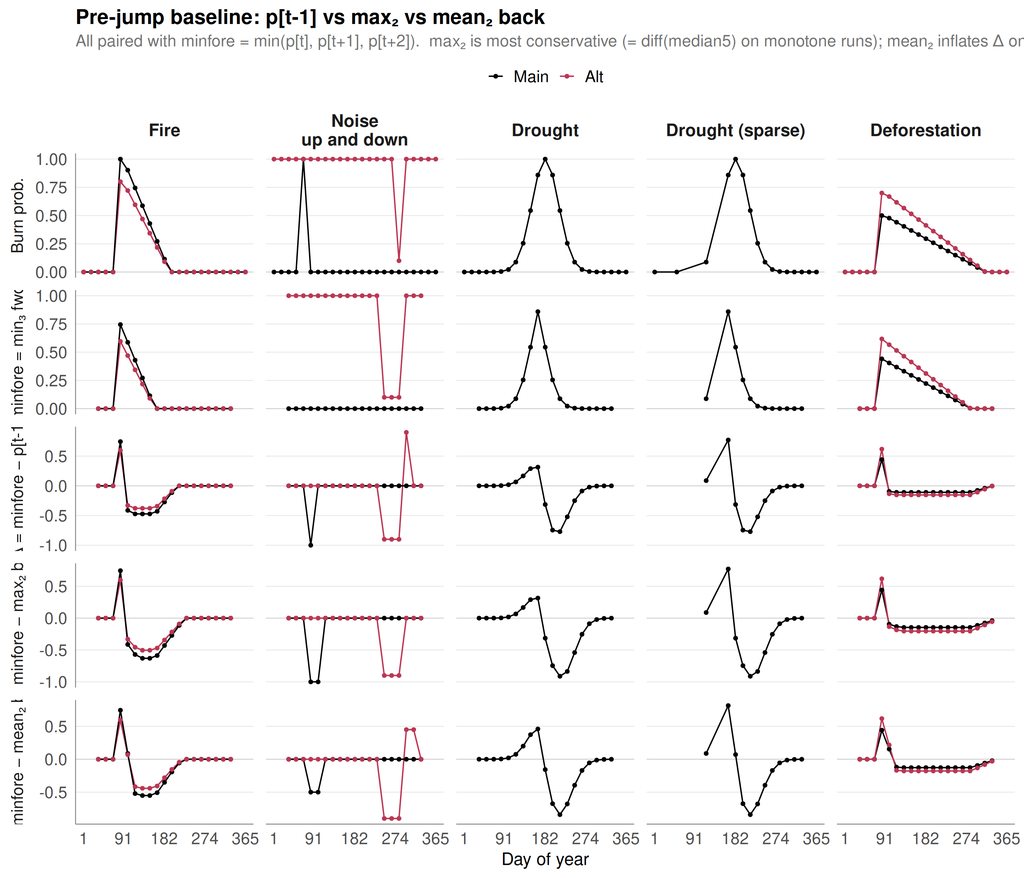

```r
var_ws3_labels <- c(
  prob       = "Burn prob.",
  minfore    = "minfore = min₃ fwd",
  delta_prev = "Δ = minfore − p[t-1]",
  delta_max  = "Δ = minfore − max₂ back",
  delta_mean = "Δ = minfore − mean₂ back"
)

ggplot(df_ws3, aes(x = doy, y = value,
                   group = signal_id, colour = color_grp)) +
  geom_hline(yintercept = 0, colour = "grey80", linewidth = 0.35) +
  geom_line(linewidth = 0.65) +
  geom_point(size = 1.1) +
  facet_grid(
    variable ~ case,
    scales   = "free_y",
    switch   = "y",
    labeller = labeller(variable = var_ws3_labels, case = case2_labels)
  ) +
  scale_colour_manual(
    name   = NULL,
    values = c(Main = "#000004", Alt = "#BB3754"),
    breaks = c("Main", "Alt")
  ) +
  scale_x_continuous(breaks = c(1, 91, 182, 274, 365)) +
  labs(
    x        = "Day of year",
    y        = NULL,
    title    = "Pre-jump baseline: p[t-1] vs max₂ vs mean₂ back",
    subtitle = paste0(
      "All paired with minfore = min(p[t], p[t+1], p[t+2]).  ",
      "max₂ is most conservative (= diff(median5) on monotone runs); ",
      "mean₂ inflates Δ on slow ramps (drought); p[t-1] is most local but noisiest."
    )
  )
```

## Order statistics vs. rolling means: `min−max` vs `mean−mean`

The exported metric (`delta3` / `delta2` in `functions.py::compute_bp_ts_metrics`) is a **window difference** at anchor `t`: a `K`-obs pre window `[t-K … t-1]` and a `K`-obs post window `[t … t+K-1]`, reduced and subtracted. The code uses **order statistics**:

$$\Delta^{\text{ord}}_{K,t} \;=\; \underbrace{\min(p_t,\dots,p_{t+K-1})}_{\text{minfore}}
\;-\; \underbrace{\max(p_{t-K},\dots,p_{t-1})}_{\text{maxback}} .$$

The proposed cheaper variant keeps the *same two windows* but swaps the reducers for **means** (one rolling-mean pass, then a fixed-offset difference of the mean array, `meansArr[t] − meansArr[t-K]`):

$$\Delta^{\text{mean}}_{K,t} \;=\; \overline{p}_{[t,\,t+K-1]} \;-\; \overline{p}_{[t-K,\,t-1]} .$$

So the only change is *min/max → mean*. Three things follow, and they are in tension:

1. **Compute.** `mean` drops the two `arrayReduce(min/max)` calls (it is element-wise addition over the array), but `min`/`max` over a length-`K` axis is selection — O(`K`), not a sort. The genuinely costly ordering op is the `arraySort` that finds the argmax `t*`, and **that is unchanged**. Net: a small constant saving, not an order of magnitude.
2. **Signal (your first intuition — higher maximum).** `min−max` is the *most conservative* jump: it needs **every** post obs above **every** pre obs (a fully separated step). A fire caught **mid-window** — post `= {0.05, 0.98, 0.98}` — gives `min = 0.05 ⇒ Δ ≈ 0` (missed), whereas `mean = 0.67 ⇒ Δ ≈ 0.62` (detected). So `mean−mean` has a higher max and catches partial-window / low-severity transitions that `min−max` discards.
3. **Null (your second intuition — higher no-signal floor).** Under pure noise the order statistics are *biased*: `E[min(post)] < μ < E[max(pre)]`, so `E[Δ^{ord}] < 0` — noise produces **negative** deltas, pushing the null *below* zero. The means are unbiased: `E[Δ^{mean}] = 0`, variance `2σ²/K`, so ~half of pure-noise anchors are **positive** and the floor sits higher — your intuition is correct on the floor. **But a higher floor is not the same as worse detection.** The mean also has lower *variance*, and against symmetric noise that variance reduction wins: the Monte-Carlo below shows `mean−mean` *out*-separating `min−max` vs iid noise. The floor argument only bites against the **right** confounder.

That confounder is a **single spike**, not symmetric noise. One bright obs (a cloud/sensor artifact) barely dents a window *min* but drags a window *mean* up by `≈ 1/K` of its height — and `max`-back is purpose-built to catch a pre-period spike. So `mean−mean`’s floor blows up exactly where it matters and `min−max`’s order statistics are robust. There is also a confound unique to the mean: the mid-window high-severity case `{0.05,0.98,0.98}` (mean `0.67`) is **indistinguishable** from a *uniform low-severity* fire `{0.67,0.67,0.67}` (mean `0.67`) — it collapses severity and window-phase into one number. Same lesson as the previous section (`meanback` inflated Δ on ramps); means on **both** sides double it. The Monte-Carlo makes the spike-vs-noise flip explicit.

```r
# Window-difference jump at anchor t: K-obs pre window [t-K .. t-1] and K-obs
# post window [t .. t+K-1], reduced two ways and subtracted.
#   delta_ord  = min(post) - max(pre)    <- the exported metric (delta3 / delta2)
#   delta_mean = mean(post) - mean(pre)  <- the rolling-mean-difference variant
# Anchor t valid on K+1 .. n-K+1; Δ dated at d[t] (first post obs).
delta_windows <- function(p, d, K) {
  nn <- length(p)
  t0 <- K + 1L; t1 <- nn - K + 1L
  if (t1 < t0) return(NULL)
  tt <- t0:t1
  post_min <- post_mean <- pre_max <- pre_mean <- numeric(length(tt))
  for (j in seq_along(tt)) {
    t    <- tt[j]
    post <- p[t:(t + K - 1L)]
    pre  <- p[(t - K):(t - 1L)]
    post_min[j]  <- min(post);  post_mean[j] <- mean(post)
    pre_max[j]   <- max(pre);   pre_mean[j]  <- mean(pre)
  }
  tibble(doy = d[tt],
         delta_ord  = post_min  - pre_max,
         delta_mean = post_mean - pre_mean)
}

build_wd <- function(sig) {
  out <- list(prob = tibble(doy = sig$obs$d, value = sig$obs$p))
  for (K in c(3L, 2L)) {
    w <- delta_windows(sig$obs$p, sig$obs$d, K)
    if (!is.null(w)) {
      out[[paste0("delta_ord",  K)]] <- tibble(doy = w$doy, value = w$delta_ord)
      out[[paste0("delta_mean", K)]] <- tibble(doy = w$doy, value = w$delta_mean)
    }
  }
  out
}

var_wd_levels <- c("prob", "delta_ord3", "delta_mean3", "delta_ord2", "delta_mean2")

df_wd <- purrr::imap_dfr(signals_ws, function(sig, sig_id) {
  mets <- build_wd(sig)
  purrr::map_dfr(intersect(var_wd_levels, names(mets)), function(vr) {
    mets[[vr]] |> mutate(signal_id = sig_id, case = sig$case,
                         level = sig$level, variable = vr)
  })
}) |>
  mutate(
    case     = factor(case,     levels = case2_levels),
    variable = factor(variable, levels = var_wd_levels),
    color_grp = dplyr::case_when(
      case == "fire"          & level == "0.80" ~ "Alt",
      case == "noise"         & level == "down" ~ "Alt",
      case == "deforestation" & level == "0.70" ~ "Alt",
      TRUE                                      ~ "Main"
    )
  )
```

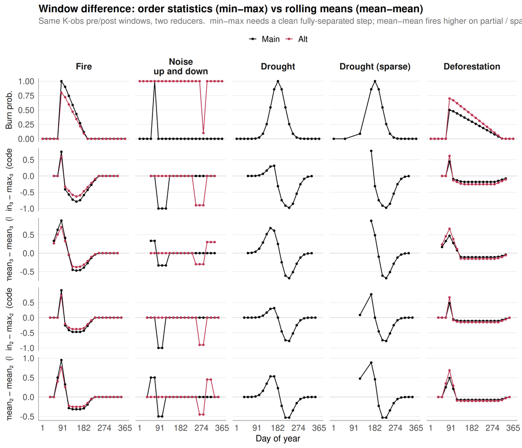

```r
var_wd_labels <- c(
  prob        = "Burn prob.",
  delta_ord3  = "Δ = min₃ − max₃  (code, K=3)",
  delta_mean3 = "Δ = mean₃ − mean₃  (K=3)",
  delta_ord2  = "Δ = min₂ − max₂  (code, K=2)",
  delta_mean2 = "Δ = mean₂ − mean₂  (K=2)"
)

ggplot(df_wd, aes(x = doy, y = value, group = signal_id, colour = color_grp)) +
  geom_hline(yintercept = 0, colour = "grey80", linewidth = 0.35) +
  geom_line(linewidth = 0.65) +
  geom_point(size = 1.1) +
  facet_grid(
    variable ~ case,
    scales   = "free_y",
    switch   = "y",
    labeller = labeller(variable = var_wd_labels, case = case2_labels)
  ) +
  scale_colour_manual(
    name = NULL, values = c(Main = "#000004", Alt = "#BB3754"),
    breaks = c("Main", "Alt")
  ) +
  scale_x_continuous(breaks = c(1, 91, 182, 274, 365)) +
  labs(
    x        = "Day of year",
    y        = NULL,
    title    = "Window difference: order statistics (min−max) vs rolling means (mean−mean)",
    subtitle = paste0(
      "Same K-obs pre/post windows, two reducers.  min−max needs a clean fully-separated step; ",
      "mean−mean fires higher on partial / sparse-drought windows (see drought_sparse, noise)."
    )
  )
```

### The deciding question: does the larger signal survive the larger null?

The deterministic panels show *signal* behaviour but not the *null*, and a “higher floor” only matters relative to how it separates from fire. Detection thresholds the **annual max** of Δ over `t`, so the right object is the distribution of that annual max under each process. Crucially, the null is **not just symmetric noise** — the real false positives are **transient spikes** (single-obs cloud/sensor artifacts) and **drought ramps**. We simulate a faint fire against all three and compare.

> **Why the null class matters.** Against symmetric iid noise, `mean−mean` actually *wins*: variance reduction (`σ²/K`) more than offsets its higher mean floor. But a single high **spike** inflates a window *mean* far more than it survives a window *min* — and `max`-back is built to catch a pre-period spike. So the comparison flips entirely depending on which confounder you test against. That flip is the whole point.

```r
set.seed(42)
n_obs  <- 23L      # obs per year (matches the synthetic sampling)
R      <- 3000L    # Monte-Carlo replicates per class
b0     <- 0.06     # unburned baseline mean prob
sd0    <- 0.10     # per-obs noise sd (truncated to [0,1])
sev    <- 0.30     # FAINT post-fire mean prob (the hard, decision-relevant regime)
t_fire <- 12L      # fire onset observation (mid-year)

trunc01 <- function(x) pmin(pmax(x, 0), 1)

# Annual max of each estimator for one probability series.
am <- function(p) {
  d  <- seq_along(p)
  w3 <- delta_windows(p, d, 3L); w2 <- delta_windows(p, d, 2L)
  tibble(
    `min−max · K3` = max(w3$delta_ord),  `mean · K3` = max(w3$delta_mean),
    `min−max · K2` = max(w2$delta_ord),  `mean · K2` = max(w2$delta_mean)
  )
}

# One series per process kind, then its annual-max Δ for all four estimators.
#   fire    : faint step (the signal we want to keep)
#   noise   : iid noise only          (symmetric — favours the mean)
#   spike   : iid noise + one ~0.95 single-obs spike (favours min−max strongly)
#   drought : slow monotone ramp + iid noise (hard for both; handled elsewhere)
gen <- function(kind) {
  p <- trunc01(rnorm(n_obs, b0, sd0))
  if (kind == "fire")    p[t_fire:n_obs] <- trunc01(rnorm(n_obs - t_fire + 1L, sev, sd0))
  if (kind == "spike")   p[sample(2:(n_obs - 1L), 1)] <- trunc01(rnorm(1, 0.95, 0.05))
  if (kind == "drought") p <- trunc01(seq(0, 0.55, length.out = n_obs) + rnorm(n_obs, 0, sd0))
  am(p)
}

class_levels <- c("fire (faint)", "noise", "spike", "drought ramp")
kinds        <- c(fire = "fire (faint)", noise = "noise",
                  spike = "spike", drought = "drought ramp")
est_levels   <- c("min−max · K3", "mean · K3", "min−max · K2", "mean · K2")

df_mc <- purrr::imap_dfr(kinds, function(lab, k) {
  purrr::map_dfr(seq_len(R), ~gen(k)) |> mutate(class = lab)
}) |>
  pivot_longer(-class, names_to = "estimator", values_to = "annual_max") |>
  mutate(estimator = factor(estimator, levels = est_levels),
         class     = factor(class, levels = class_levels))
```

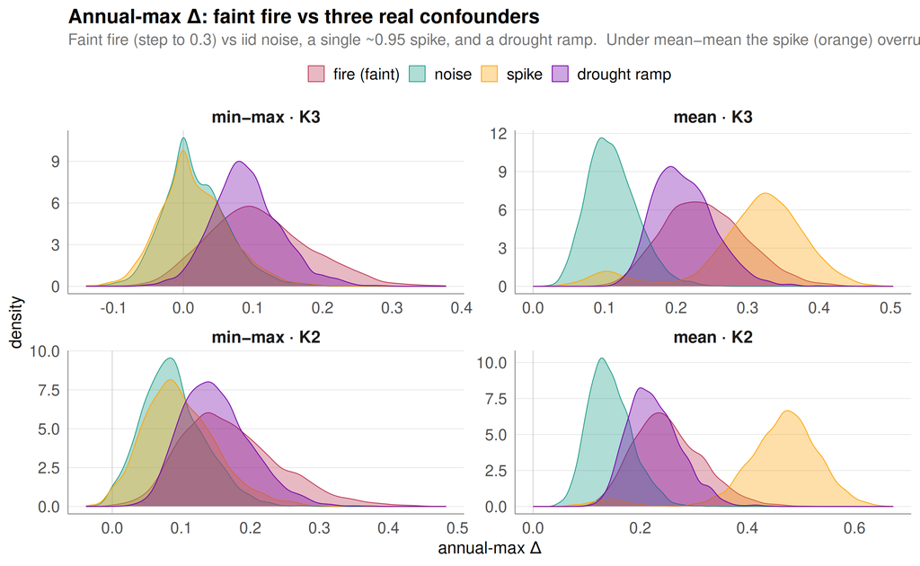

```r
mc_cols <- c("fire (faint)" = "#BB3754", "noise" = "#1F9E89",
             "spike" = "#FCA50A", "drought ramp" = "#7301A8")
ggplot(df_mc, aes(annual_max, fill = class, colour = class)) +
  geom_vline(xintercept = 0, colour = "grey80", linewidth = 0.35) +
  geom_density(alpha = 0.35, linewidth = 0.4) +
  facet_wrap(~estimator, ncol = 2, scales = "free") +
  scale_fill_manual(name = NULL, values = mc_cols) +
  scale_colour_manual(name = NULL, values = mc_cols) +
  labs(
    x = "annual-max Δ", y = "density",
    title    = "Annual-max Δ: faint fire vs three real confounders",
    subtitle = paste0(
      "Faint fire (step to ", sev, ") vs iid noise, a single ~0.95 spike, and a drought ramp.  ",
      "Under mean−mean the spike (orange) overruns the fire; under min−max it stays low."
    )
  )
```

```r
# Per estimator, AUC of the faint fire against EACH confounder (rank-based; 0.5 =
# chance, <0.5 = the confounder scores HIGHER than fire, i.e. worse than useless).
auc_fn <- function(pos, neg) {
  r <- rank(c(pos, neg))
  (sum(r[seq_along(pos)]) - length(pos) * (length(pos) + 1) / 2) /
    (length(pos) * length(neg))
}
fire_vals <- df_mc |> filter(class == "fire (faint)")
sep_tbl <- df_mc |>
  filter(class != "fire (faint)") |>
  group_by(estimator, confounder = class) |>
  summarise(
    AUC = auc_fn(fire_vals$annual_max[fire_vals$estimator == dplyr::first(estimator)],
                 annual_max),
    .groups = "drop"
  ) |>
  tidyr::pivot_wider(names_from = confounder, values_from = AUC)
knitr::kable(sep_tbl, digits = 3,
             caption = "AUC of faint fire vs each confounder (rank-based; <0.5 = confounder wins).")
```

AUC of faint fire vs each confounder (rank-based; <0.5 = confounder wins).

| estimator | noise | spike | drought ramp |
| --- | --- | --- | --- |
| min−max · K3 | 0.861 | 0.857 | 0.571 |
| mean · K3 | 0.978 | 0.209 | 0.656 |
| min−max · K2 | 0.845 | 0.799 | 0.582 |
| mean · K2 | 0.933 | 0.051 | 0.618 |

**Reading it.** Your two intuitions both hold — `mean−mean` posts a higher signal *and* a higher floor — but whether that nets out **depends entirely on the confounder**:

- **vs iid noise** — `mean−mean` *wins* (higher AUC). Variance reduction (`σ²/K`) beats its higher mean floor; against symmetric noise the mean is genuinely the better detector. So the plain “means are noisier” story is *too pessimistic* — for symmetric noise it’s the opposite.
- **vs a single spike** — `mean−mean` is **catastrophic** (AUC ≪ 0.5: the spike scores higher than real fire). One bright obs dominates a window *mean*; a window *min* shrugs it off and `max`-back actively guards the pre side. Single-obs artifacts are pervasive in real Landsat burn-prob series, so this case dominates the decision.
- **vs a drought ramp** — both are weak (AUC near chance); raw Δ is the wrong tool here, which is why the notebook leans on gap-weighting and persistence (`min₃`, `J = Δp·min₃`) for drought, not on the choice of reducer.

**Bottom line.** Keep `min−max` (the current `delta3`/`delta2`) as the **primary** exported metric — its spike robustness is non-negotiable on real imagery, and the compute saving from `mean` is marginal (the `arraySort` for the argmax stays either way). `mean−mean` is worth carrying only as a **secondary, persistence-gated** channel for the clean low-severity forest-burn regime (e.g. `mean₃ × minfore`, or `mean` thresholded *after* a `min`-based spike guard), where its better SNR against symmetric noise can be cashed in without letting spikes through.